# CSE4CG-PyOpenGL-Lab-06

## 5143135: Computer Graphics @ ZJU School of Software Technology

## Lab 6: Ray Tracing

Welcome to **5143135: Computer Graphics** !

After attending this lab class, you are expected to

- Understand how to implement a simple ray tracing application, which supports shadows and reflections, without OpenGL in Python.

**This lab class is based on the previous one on ray casting.**

### Task 1: Specular Highlights

Before implementing **ray tracing**, let's first accomplish the **Phong reflection model**, as illustrated below.

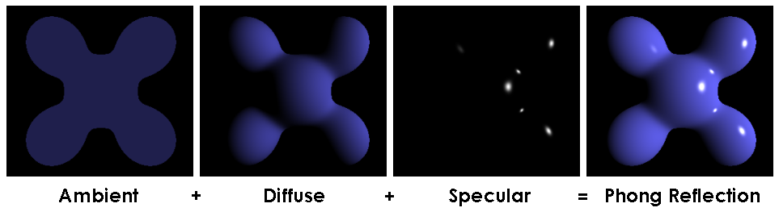

In the previous lab class, we managed to enable **ambient** and **diffuse** reflections. In addition, if a surface is shiny, there will be small intense **specular** highlights in its reflection against the light. To enbale the contribution of specular highlights, we need the following **global** parameters.

```python
specular_c  = 1.0
specular_k  = 50.0
```

The amount of contribution relates to the normal, the directions to the light and the camera, and the light's color, as follows, which is then added to the pixel's color.

```python
toO = normalize(O - P)

# Blinn-Phong shading (specular).
color_ray += obj.get('specular_c', specular_c) * max(np.dot(N, normalize(toL + toO)), 0) ** specular_k * color_light
```

Then we can rename the original *cast_ray* function to *trace_ray*, and update it as follows.

```python
def trace_ray(rayO, rayD):
    # Find first point of intersection with the scene.
    t = np.inf
    for i, obj in enumerate(scene):
        t_obj = intersect(rayO, rayD, obj)
        if t_obj < t:
            t, obj_idx = t_obj, i

    # Return None if the ray does not intersect any object.
    if t == np.inf:
        return

    # Find the object.
    obj = scene[obj_idx]

    # Find the point of intersection on the object.
    P = rayO + rayD * t

    # Find properties of the object.
    N = get_normal(obj, P)
    color = get_color(obj, P)
    toL = normalize(L - P)
    toO = normalize(O - P)

    # Start computing the color.
    color_ray = ambient

    # Lambert shading (diffuse).
    color_ray += obj.get('diffuse_c', diffuse_c) * max(np.dot(N, toL), 0) * color

    # Blinn-Phong shading (specular).
    color_ray += obj.get('specular_c', specular_c) * max(np.dot(N, normalize(toL + toO)), 0) ** specular_k * color_light

    return obj, P, N, color_ray
```

Note that we also need to update the statements in the program where *cast_ray* was called. Then, run the program and observe the output image, as follows. **Can you describe how rendering is improved after introducing the specular highlights?**

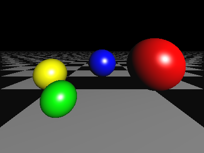

### Task 2: Shadows

We continute to modify the *trace_ray* function for **shadows**. In Lecture 7, we discussed that, if there is only **ONE** light, whether a location **P** (i.e., the intersection obtained in ray casting) is shadowed can be detected by casting a **shadow ray** from **P** to the light's position **L**. For each object in the scene, if **any of them** intersects with the shadow ray, then **P** is shadowed.

Besides, in order to avoid **self-shadows**, we usually add a tiny displacement along the normal **N**, known as **epsilon**, to **P** as the new origin of the shadow ray. Suppose any shadowed location is drawn as a black pixel, the following loop, after ray-casting intersection detection but before color calculation, enbales the shadows.

```python
# Shadow (with epsilon)
P_e = P + N * 0.0001
for k, obj_sh in enumerate(scene):
    l = intersect(P_e, toL, obj_sh)
    if l < np.inf:
        return
```

Now please organize the *trace_ray* function as follows and run it.

```python
def trace_ray(rayO, rayD):
    # Find first point of intersection with the scene.
    t = np.inf
    for i, obj in enumerate(scene):
        t_obj = intersect(rayO, rayD, obj)
        if t_obj < t:
            t, obj_idx = t_obj, i

    # Return None if the ray does not intersect any object.
    if t == np.inf:
        return

    # Find the object.
    obj = scene[obj_idx]

    # Find the point of intersection on the object.
    P = rayO + rayD * t

    # Find properties of the object.
    N = get_normal(obj, P)
    color = get_color(obj, P)
    toL = normalize(L - P)
    toO = normalize(O - P)

    # Shadow (with epsilon)
    P_e = P + N * 0.0001
    for k, obj_sh in enumerate(scene):
        l = intersect(P_e, toL, obj_sh)
        if l < np.inf:
            return

    # Start computing the color.
    color_ray = ambient

    # Lambert shading (diffuse).
    color_ray += obj.get('diffuse_c', diffuse_c) * max(np.dot(N, toL), 0) * color

    # Blinn-Phong shading (specular).
    color_ray += obj.get('specular_c', specular_c) * max(np.dot(N, normalize(toL + toO)), 0) ** specular_k * color_light

    return obj, P, N, color_ray
```

After observing the output image as follows, **can you describe how rendering is improved after introducing the shadows?**

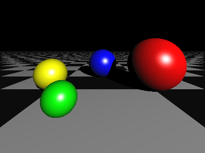

### Task 3: Reflections

In Lecture 7, we mentioned that reflections are implemented by a **recursive** call of ray tracing with the reflection ray, which stops regarding **resursion depth** or **ray contribution**. In this lab class, we assume the recursion depth only **ONE** for now (i.e., reflections are done once) and implement it in a **non-recursive** way.

In particular, we conduct the reflection ray tracing after the eye ray tracing in the main loop, instead of doing it inside the *trace_ray* function. Note we add epsilon to the reflection ray, in order to avoid **self-reflections**, similar to self-shadows. The main loop is updated as follows.

```python
# Loop through all pixels in the image
for i, x in enumerate(np.linspace(x_min, x_max, w)):
    for j, y in enumerate(np.linspace(y_min, y_max, h)):
        color_pixel[:] = 0

        Q[0] = x
        Q[1] = y
        D = normalize(Q - O)

        # Initial ray (from camera to pixel)
        rayO, rayD = O, D

        flag = trace_ray(rayO, rayD)
        if not flag:
            continue
        obj, P, N, color_ray = flag
        color_pixel = color_ray

        # Reflection ray (with epsilon)
        P_e = P + N * 0.0001
        R = normalize(rayD - 2 * np.dot(rayD, N) * N)
        flag = trace_ray(P_e, R)
        if flag:
            obj, P, N, color_ray = flag
            reflection = obj.get('reflection', 1.0)
            color_pixel += reflection * color_ray

        img[h - j - 1, i, :] = np.clip(color_pixel, 0, 1)
```

Now please organize the entire program as follows and run it.

```python
import numpy as np
import matplotlib.pyplot as plt


def normalize(x):
    x /= np.linalg.norm(x)
    return x

def intersect_plane(O, D, P, N):
    # Return the distance from O to the intersection of the ray (O, D) with the
    # plane (P, N), or +inf if there is no intersection.
    # O and P are 3D points, D and N (normal) are normalized vectors.
    denominator = np.dot(N, D)
    if np.abs(denominator) < 1e-6:
        return np.inf

    t = (np.dot(N, P) - np.dot(N, O)) / denominator
    if t < 0:
        return np.inf
    return t

def intersect_sphere(O, D, S, R):
    # Return the distance from O to the intersection of the ray (O, D) with the
    # sphere (S, R), or +inf if there is no intersection.
    # O and S are 3D points, D (direction) is a normalized vector, R is a scalar.
    # It is necessary to consider the case that the sphere's centre is not at the origin
    # H(P) = (P - S) * (P - S) - R * R = 0
    OS = O - S

    a = np.dot(D, D)
    b = 2 * np.dot(D, OS)
    c = np.dot(OS, OS) - R * R
    discriminant = b * b - 4 * a * c

    if discriminant > 0:
        d = np.sqrt(discriminant)

        t_0 = (-b + d) / (2 * a)
        t_1 = (-b - d) / (2 * a)

        if t_0 < 0:
            return np.inf
        elif t_1 < 0:
            return t_0
        else:
            return t_1
    else:
        return np.inf


def intersect(O, D, obj):
    if obj['type'] == 'plane':
        return intersect_plane(O, D, obj['position'], obj['normal'])
    elif obj['type'] == 'sphere':
        return intersect_sphere(O, D, obj['position'], obj['radius'])


def get_normal(obj, M):
    # Find normal.
    if obj['type'] == 'sphere':
        N = normalize(M - obj['position'])
    elif obj['type'] == 'plane':
        N = obj['normal']
    return N


def get_color(obj, P):
    color = obj['color']
    if not hasattr(color, '__len__'):
        color = color(P)
    return color

def trace_ray(rayO, rayD):
    # Find first point of intersection with the scene.
    t = np.inf
    for i, obj in enumerate(scene):
        t_obj = intersect(rayO, rayD, obj)
        if t_obj < t:
            t, obj_idx = t_obj, i

    # Return None if the ray does not intersect any object.
    if t == np.inf:
        return

    # Find the object.
    obj = scene[obj_idx]

    # Find the point of intersection on the object.
    P = rayO + rayD * t

    # Find properties of the object.
    N = get_normal(obj, P)
    color = get_color(obj, P)
    toL = normalize(L - P)
    toO = normalize(O - P)

    # Shadow (with epsilon)
    P_e = P + N * 0.0001
    for k, obj_sh in enumerate(scene):
        l = intersect(P_e, toL, obj_sh)
        if l < np.inf:
            return

    # Start computing the color.
    color_ray = ambient

    # Lambert shading (diffuse).
    color_ray += obj.get('diffuse_c', diffuse_c) * max(np.dot(N, toL), 0) * color

    # Blinn-Phong shading (specular).
    color_ray += obj.get('specular_c', specular_c) * max(np.dot(N, normalize(toL + toO)), 0) ** specular_k * color_light

    return obj, P, N, color_ray


def add_sphere(position, radius, color):
    return dict(type='sphere',
                position=np.array(position),
                radius=np.array(radius),
                color=np.array(color),
                reflection=0.5)


def add_plane(position, normal):
    return dict(type='plane',
                position=np.array(position),
                normal=np.array(normal),
                color=lambda P : (color_white if (int(P[0]) % 2) == (int(P[2]) % 2) else color_black),
                diffuse_c=0.75,
                specular_c=0.5,
                reflection=0.25)

# Image's width and height (in pixels)
w, h = 400, 300

# Image's aspect ratio
r = float(w) / h

# Ranges of image coordinates (-1 <= x <= 1, -1 <= y <= 1)
# But the actual y coordinates need to be divided by the aspect ratio, why?
x_min, x_max = -1.0, 1.0
y_min, y_max = -1.0 / r, 1.0 / r

# Output image data, in RGB channels
img = np.zeros((h, w, 3))

# Camera point
O = np.array([0.0, 0.25, -1.0])

# The point in the image plane to which the camera points to (z is always 0)
# Its x and y coordinates will be updated in ray casting / tracing
# In the view coordinate system, the positive direction of z-axis is against the camera
Q = np.array([0.0, 0.0, 0.0])

# Light's position
L = np.array([5.0, 5.0, -10.0])

# Light's color (white)
color_light = np.ones(3)

# Image pixel's color (black by default, i.e. drawing nothing)
# It will be updated if the ray hits an object
color_pixel = np.zeros(3)

color_white = np.ones(3)
color_black = np.zeros(3)

# List of objects
scene = [
    add_sphere([1.0, 0.0, 1.0], 0.5, [1.0, 0.0, 0.0]),
    add_sphere([0.0, -0.1, 2.0], 0.4, [0.0, 0.0, 1.0]),
    add_sphere([-1.0, -0.2, 1.0], 0.3, [1.0, 1.0, 0.0]),
    add_sphere([-0.5, -0.3, 0.2], 0.2, [0.0, 1.0, 0.0]),
    add_plane([0.0, -0.5, 0.0], [0.0, 1.0, 0.0]),
]

# Default light and material parameters
ambient     = 0.05
diffuse_c   = 1.0
specular_c  = 1.0
specular_k  = 50.0

# Loop through all pixels in the image
for i, x in enumerate(np.linspace(x_min, x_max, w)):
    for j, y in enumerate(np.linspace(y_min, y_max, h)):
        color_pixel[:] = 0

        Q[0] = x
        Q[1] = y
        D = normalize(Q - O)

        # Initial ray (from camera to pixel)
        rayO, rayD = O, D

        flag = trace_ray(rayO, rayD)
        if not flag:
            continue
        obj, P, N, color_ray = flag
        color_pixel = color_ray

        # Reflection ray (with epsilon)
        P_e = P + N * 0.0001
        R = normalize(rayD - 2 * np.dot(rayD, N) * N)
        flag = trace_ray(P_e, R)
        if flag:
            obj, P, N, color_ray = flag
            reflection = obj.get('reflection', 1.0)
            color_pixel += reflection * color_ray

        img[h - j - 1, i, :] = np.clip(color_pixel, 0, 1)

plt.imsave('L6.png', img)
```

After observing the output image as follows, **can you describe how rendering is improved after introducing the reflections?**

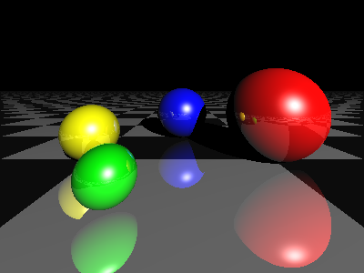

### Questions

#### Q1: Think about how you will modify the program when there are mutiple point lights.

#### Q2: Think about how you will implement reflections in a recursive way (i.e., the main loop only deals with eye rays and the trace_ray function deals with reflection rays) when recursion depth is more than 1.

#### Q3: Modify the light and material parameters and see what differences are made in rendering.